# Domínios Gov.br

Théo Albuquerque de Paula

2019-03-19

Hoje, nós iremos analisar o banco de dados relacionados aos domínios que terminam em Gov.br, que pode ser encontrado nesse [link](http://dados.gov.br/dataset/dominios-gov-br). A iniciativa de disponibilizar dados públicos e abertos pode ser encontrado no site dos [Dados Abertos](http://dados.gov.br/).

Para entender melhor o banco de dados a ser analisado, abaixo segue o dicionário das variáveis.

## Dicionário de Dados

| Campo | Tipo | Descrição |
| --- | --- | --- |
| dominio | Texto | URL cadastrada no Registro.br |
| documento | Texto | Número do documento informado ao Registro.br no cadastro da URL |
| nome | Texto | Nome do Órgão ou Entidade responsável pela URL cadastrada |
| uf | Texto | Unidade da federação que Órgão ou Entidade informou ao cadastrar a URL no Registro.br |
| cidade | Texto | Cidade que Órgão ou Entidade informou ao cadastrar a URL no Registro.br |
| cep | Texto | CEP que Órgão ou Entidade informou ao cadastrar a URL no Registro.br |
| data_cadastro | Data/Hora | Data em que o domínio foi registrado |
| ultima_atualizacao | Data/Hora | Data em que o domínio sofreu a última atualização |
| ticket | Inteiro | Número do ticket vinculado ao registro da URL no cadastro do Registro.br |

## Análise de Dados

### Registros por ano

Existem 1615 sites com domínios Gov.br. Sendo o site mais antigo a ser registrado é o gdf.gov.br, na data 07 de abril de 1995, e o mais novo é o centelha.gov.br, na data 12 de março de 2019.

Abaixo segue o histograma de registros de domínio por ano:

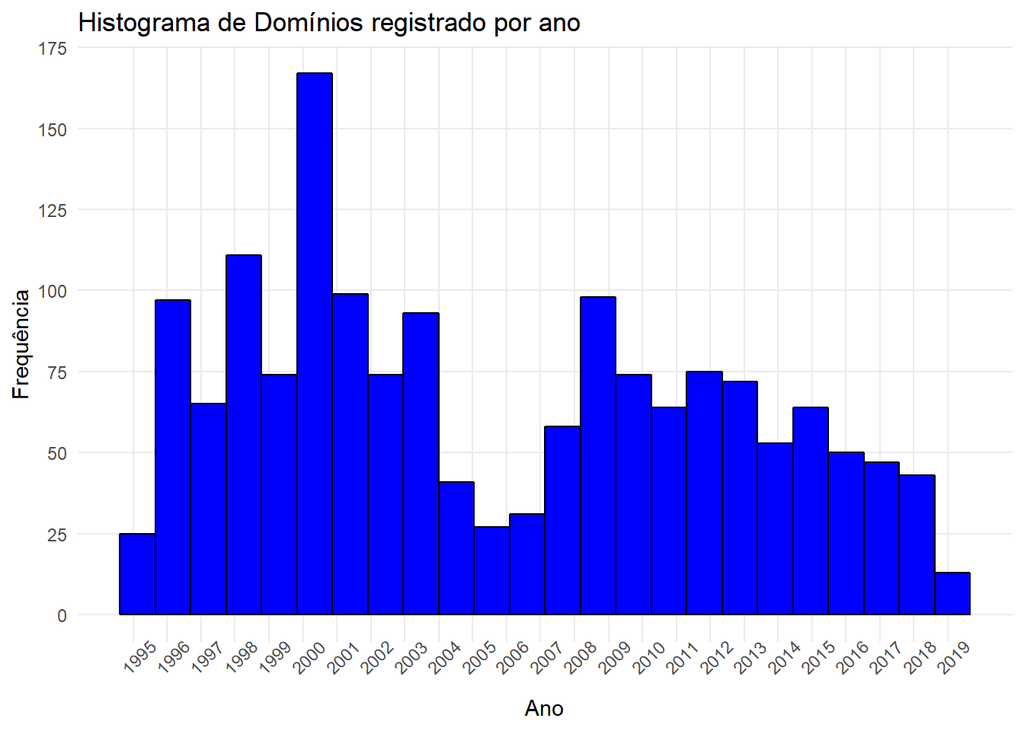

### Última atualização do site

Há 189 domínios que foram lançados, mas depois não foram mais atualizados. O domínio que foi lançado e não foi mais atualizado é o http://xn--previdnciasocial-xqb.gov.br e o mais novo é o http://centelha.gov.br. Você ver os demais na tabela abaixo:

[interactive table not shown]

### Órgãos

Os domínios registrados pertencem a 611 órgãos. Alguns órgãos registraram mais de um domínio Gov.br por causa dos serviços que prestam, como a Caixa Econômica Federal que presta os serviços de loteria, de empréstimos pessoais/corporativos e de financiamentos culturais. Às vezes um domínio Gov.br é registrado por causa da proximidade dos nomes dos órgãos e redireciona para o site principal.

|  | Órgão | Quantidade |
| --- | --- | --- |
| 1 | CAIXA ECONOMICA FEDERAL | 81 |
| 2 | Ministerio do Planejamento, Orcamento e Gestao | 75 |
| 3 | SERVICO FEDERAL DE PROCESSAMENTO DE DADOS - SERPRO | 55 |
| 4 | PRESIDÊNCIA DA REPÚBLICA | 43 |
| 5 | MINISTÉRIO DA INDUSTRIA, COMERCIO EXTERIOR E SERVI | 34 |
| 6 | Conselho de Arquitetura e Urbanismo do Brasil | 29 |
| 7 | CONTROLADORIA-GERAL DA UNIÃO | 24 |
| 8 | MINISTERIO DO MEIO AMBIENTE | 23 |
| 9 | MINISTERIO DA JUSTICA | 22 |
| 10 | Ministerio do Desenvolvimento Agrario | 21 |

[output cut: 601 more lines]

### Localização

A cidade que mais possui domínios Gov.br é Brasília, pelo fato de ser a capital do Brasil. O Rio de Janeiro ainda possui muitos órgãos federais, o que justifica a segunda posição.

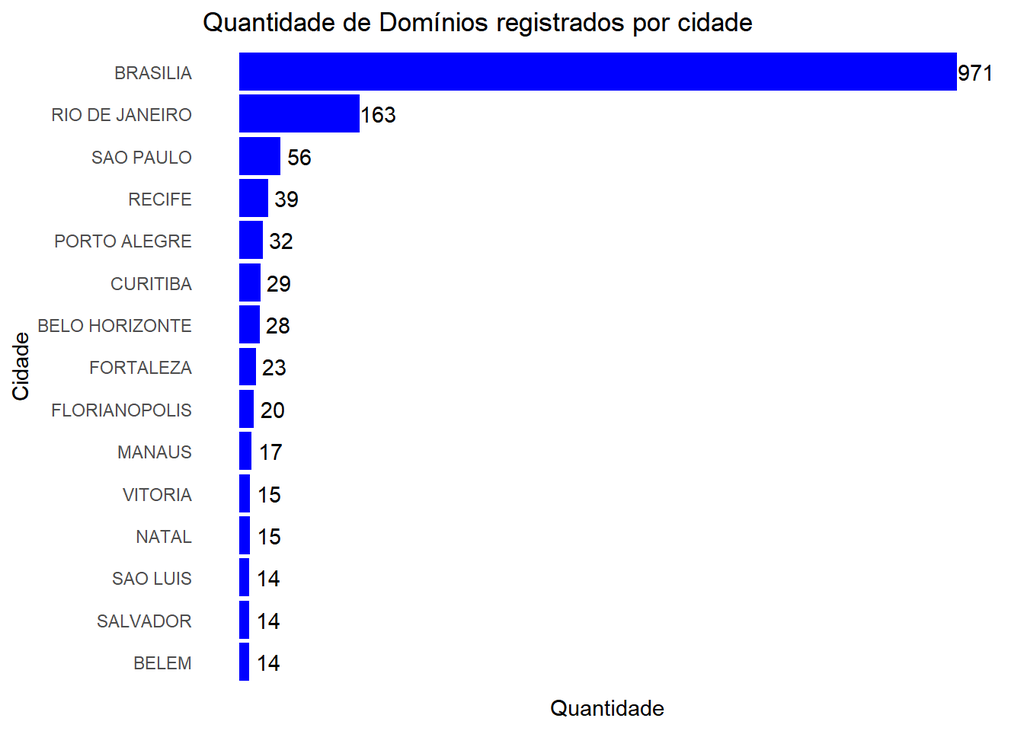

|  | Cidade | UF | Quantidade |
| --- | --- | --- | --- |
| 1 | BRASILIA | DF | 971 |
| 2 | RIO DE JANEIRO | RJ | 163 |
| 3 | SAO PAULO | SP | 56 |
| 4 | RECIFE | PE | 39 |
| 5 | PORTO ALEGRE | RS | 32 |
| 6 | CURITIBA | PR | 29 |
| 7 | BELO HORIZONTE | MG | 28 |
| 8 | FORTALEZA | CE | 23 |
| 9 | FLORIANOPOLIS | SC | 20 |
| 10 | MANAUS | AM | 17 |

[output cut: 74 more lines]

No mapa abaixo podemos ver quais cidades utilizam os domínios Gov.br:

[interactive chart not shown]

## Conclusão

É interessante perceber que a maioria dos domínios Gov.br foram registrados nas capitais, mas não exclusivas a essas cidades. É louvável que haja muitos domínios registrados por órgãos federais, o que ajuda na transparência e divulgação de notícias, mas ainda é tímida a utilização dos domínios Gov.br pelos governos estaduais e municipais.